# Understanding Linear Layer (nn.Linear) in Pytroch

## Linear Layer

Linear layer is nothing but a linear transformation. Assume an input row vector $\mathrm{x} \in \mathbb{R}^{1\times m}$, a randomly initialized matrix $W \in \mathbb{R}^{n \times m}$ and a bias vector $\mathrm{b} \in \mathbb{R}^{1\times n}$, then output vector $\mathrm{y} \in \mathbb{R}^{1\times n}$ is obtained as follows;

$$\mathrm{y} = \mathrm{x} W^{\top} + \mathrm{b}$$

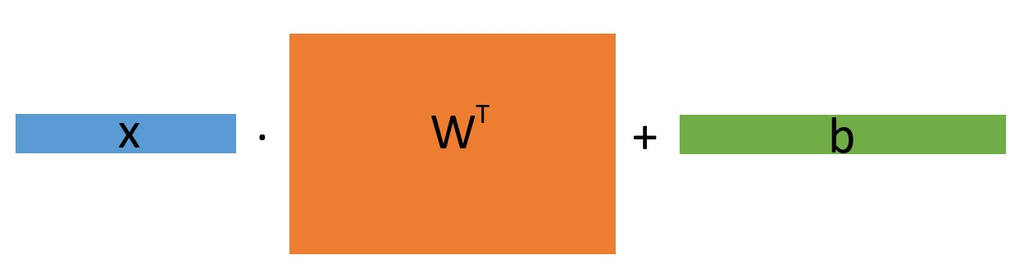

**Note**: Pytorch code assumes input vector to be a row-vector.

```python
import torch
import torch.nn as nn
```

# Instantiate One Fully-Connected Layer using nn.Linear

Assuming input row vector is $\mathrm{x} \in \mathbb{R}^{1\times 5}$ and we want an output vector $\mathrm{y} \in \mathbb{R}^{1\times 10}$, following is the code to create a linear layer for such a transformation.

```python
fc_layer = nn.Linear(in_features=5, out_features=10)

# Here we have created an object using nn.Linear class and named it as 'fc_layer'.
# Choice of name is arbitrary and user can name it with any syntactically legitimate option.
```

### We can now check the shape and values of weight matrix $W$ and bias vector $\mathrm{b}$ associated with this linear or fully-connected layer.

```python
print('Dimension of Weight Matrix: ' , fc_layer.weight.shape)
print('Dimension of Bias Vector  : ' , fc_layer.bias.shape)

print('\n\n\n')
print('Weight Matrix (W) of Fully-Connected Layer:\n\n', fc_layer.weight.data )
print('\n\n\nBias Vecotr (b) of Fully-Connected Layer:\n\n', fc_layer.bias.data )
```

```
Dimension of Weight Matrix:  torch.Size([10, 5])
Dimension of Bias Vector  :  torch.Size([10])




Weight Matrix (W) of Fully-Connected Layer:

 tensor([[-0.0786, -0.3187,  0.0387,  0.1568,  0.3270],
        [-0.1259, -0.3375, -0.0661,  0.0027, -0.0467],
        [-0.1169, -0.3655,  0.0147, -0.1011, -0.2387],
        [-0.0015,  0.0143, -0.4409, -0.0516, -0.0673],
        [-0.0113, -0.0793,  0.3626,  0.1100,  0.0828],
        [-0.0538,  0.1696, -0.1801,  0.3227,  0.2231],
        [ 0.3756,  0.1603,  0.4081,  0.4111, -0.2846],
        [-0.0029,  0.3131, -0.3981, -0.2207,  0.3479],
        [-0.0800,  0.0006, -0.3195, -0.3124, -0.2806],
        [ 0.0288,  0.1416,  0.4082, -0.2675, -0.3988]])



Bias Vecotr (b) of Fully-Connected Layer:

 tensor([ 0.2992,  0.4216,  0.1114,  0.2411,  0.1526, -0.2135,  0.3067,  0.2109,
        -0.2312,  0.0720])
```

### Now, an inut vector, lets say $\mathrm{x}=[1,2,3,4,5]$ , can be transformed into output vector using linear layer by simply passing $\mathrm{x}$ to *$fc\_layer$*.

```python
x= torch.tensor([[1,2,3,4,5]], dtype=torch.float32)

output = fc_layer(x)
```

```python
print('Dimension of Input Vector   : ' , x.shape)
print('Dimension of Output Vector  : ' , output.shape)

print('\n\nInput Vector:\n', x)
print('\n\nOutput Vector:\n', output)
```

```
Dimension of Input Vector   :  torch.Size([1, 5])
Dimension of Output Vector  :  torch.Size([1, 10])


Input Vector:
 tensor([[1., 2., 3., 4., 5.]])


Output Vector:
 tensor([[ 1.9615, -0.8003, -2.2906, -1.5969,  1.9244,  1.9377,  2.4486,  0.4968,
         -3.9212, -1.4551]], grad_fn=<AddmmBackward>)
```

### It is tempting to verify that internal computation/transformation perfomred by *$fc\_layer$* on $\mathrm{x}$ is in line with what we have in our mind. We can do so by accessing weight matrix and bias vector of *$fc\_layer$* and then computing $\mathrm{x}W^{\top}+\mathrm{b}$ externally.

```python
W = fc_layer.weight.data    # weight matrix of fc_layer
b = fc_layer.bias.data      # bias vector of fc_layer


y = x @ W.T + b             # @ operator is being used for standard vector-matrix multiplication
```

```python
print('\n\nInput Vector:\n', x)
print('\n\nOutput Vector:\n', y)
```

```
Input Vector:
 tensor([[1., 2., 3., 4., 5.]])


Output Vector:
 tensor([[ 1.9615, -0.8003, -2.2906, -1.5969,  1.9244,  1.9377,  2.4486,  0.4968,
         -3.9212, -1.4551]])
```

### Output vector obtained through $\mathrm{x}W^{\top}+\mathrm{b}$ is exactly same as the one obtained by passing $\mathrm{x}$ to Pytorch's *$fc\_layer()$*.

### Convert .IPYNB to .HTML

```python
import os
cwd = os.getcwd()
os.chdir(cwd)

!jupyter nbconvert PyTorch_LinearLayer.ipynb
```